# Social Media Dataset

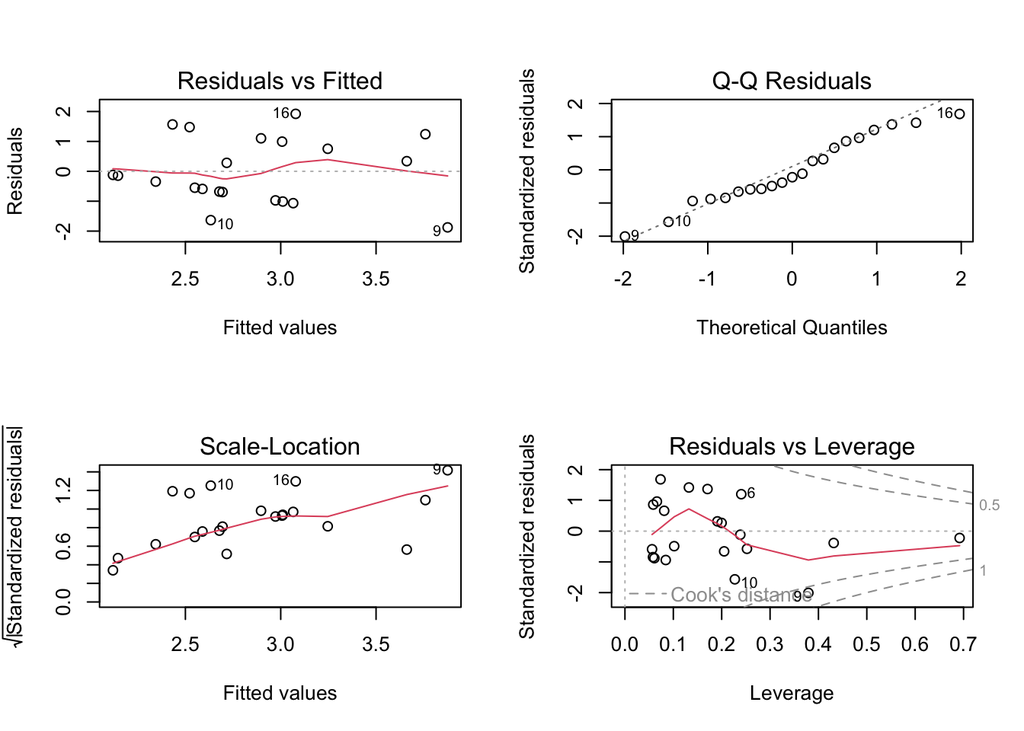

```r
# Diagnostic plots
par(mfrow = c(2, 2))
plot(model)
```

** Logistic regression **

```r
# Load necessary libraries
library(dplyr)

logit_model <- glm(Tired.waking.up.in.morning ~ Instagram_Hours + LinkedIn_Hours + Twitter_Hours, data = media, family = binomial)

# Summary of the model to view coefficients and statistics
summary(logit_model)
```

```
##
## Call:
## glm(formula = Tired.waking.up.in.morning ~ Instagram_Hours +
##     LinkedIn_Hours + Twitter_Hours, family = binomial, data = media)
##
## Coefficients:
##                 Estimate Std. Error z value Pr(>|z|)
## (Intercept)      1.64146    1.37494   1.194    0.233
## Instagram_Hours -0.07471    0.16037  -0.466    0.641
## LinkedIn_Hours  -0.42321    0.27238  -1.554    0.120
## Twitter_Hours   -1.90303    1.85025  -1.029    0.304
##
## (Dispersion parameter for binomial family taken to be 1)
##
##     Null deviance: 26.734  on 20  degrees of freedom
## Residual deviance: 20.378  on 17  degrees of freedom
## AIC: 28.378
##
## Number of Fisher Scoring iterations: 7
```

```r
library(broom)

# Get a tidy summary of the model
tidy(logit_model)
```

```
## # A tibble: 4 × 5
##   term            estimate std.error statistic p.value
##   <chr>              <dbl>     <dbl>     <dbl>   <dbl>
## 1 (Intercept)       1.64       1.37      1.19    0.233
## 2 Instagram_Hours  -0.0747     0.160    -0.466   0.641
## 3 LinkedIn_Hours   -0.423      0.272    -1.55    0.120
## 4 Twitter_Hours    -1.90       1.85     -1.03    0.304
```

```r
# Check for multicollinearity
library(car)
vif(logit_model)  # Variance Inflation Factor should ideally be below 5
```

```
## Instagram_Hours  LinkedIn_Hours   Twitter_Hours
##        1.068077        1.145762        1.135641
```

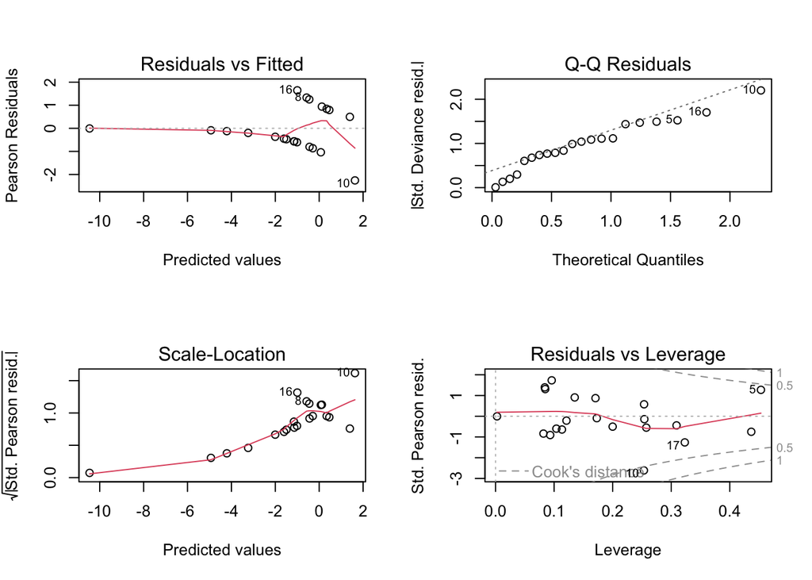

```r
# Model diagnostics plots
par(mfrow = c(2, 2))
plot(logit_model)
```

```r
# Predict probabilities
predicted_probs <- predict(logit_model, type = "response")

# Convert probabilities to binary outcome based on a 0.5 threshold
predicted_class <- ifelse(predicted_probs > 0.5, "Yes", "No")

# Confusion Matrix to evaluate model
table(Predicted = predicted_class, Actual = media$Tired.waking.up.in.morning)
```

```
##          Actual
## Predicted No Yes
##       No  12   3
##       Yes  2   4
```

```r
# Calculate accuracy
mean(predicted_class == media$Tired.waking.up.in.morning)
```

```
## [1] 0.7619048
```

**Inference**

- Logistic regression was used to predict binary outcomes such as whether a person felt tired waking up in the morning based on their social media usage. The model provided estimates of how each predictor variable (e.g., hours on Instagram, LinkedIn, Twitter) influences the likelihood of feeling tired.
- The analysis included model diagnostics to check for multicollinearity and model fit, ensuring reliable results. **Linear Discriminant Analysis**

```r
library(MASS)

media$Tired.waking.up.in.morning <- factor(media$Tired.waking.up.in.morning)

# Apply LDA
media_lda <- lda(Tired.waking.up.in.morning ~ Instagram_Hours + LinkedIn_Hours + Twitter_Hours +
                 Whatsapp_Wechat_hours + Reddit_hours + Youtube_hours + OTT_hours +
                 Mood_Productivity + Trouble.falling.asleep, data = media)

# Summary of the LDA model
summary(media_lda)
```

```
##         Length Class  Mode
## prior    2     -none- numeric
## counts   2     -none- numeric
## means   18     -none- numeric
## scaling  9     -none- numeric
## lev      2     -none- character
## svd      1     -none- numeric
## N        1     -none- numeric
## call     3     -none- call
## terms    3     terms  call
## xlevels  2     -none- list
```

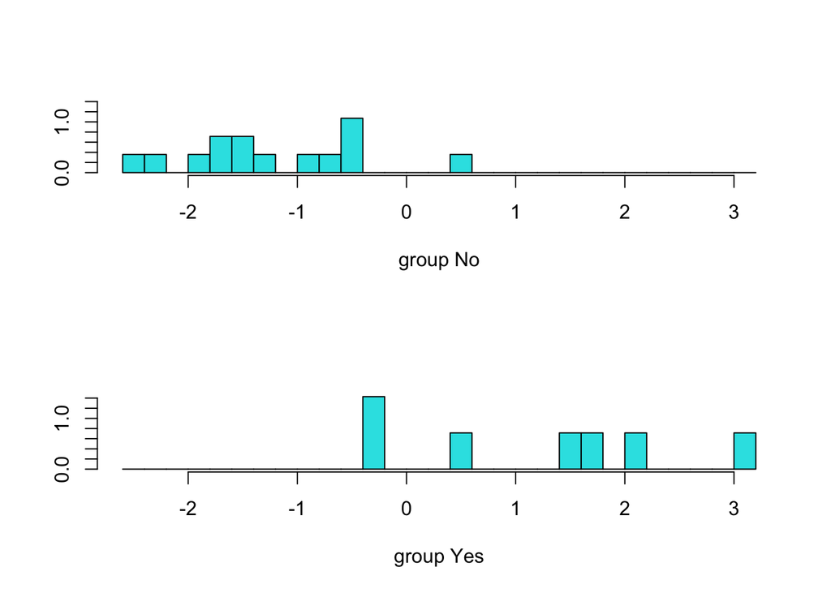

```r
# Plotting the LDA model
plot(media_lda)
```

```r
# Optionally, predicting and evaluating the model
media_predictions <- predict(media_lda)
table(predicted = media_predictions$class, actual = media$Tired.waking.up.in.morning)
```

```
##          actual
## predicted No Yes
##       No  13   2
##       Yes  1   5
```

**Inference**

- LDA was used for classifying individuals into groups based on their responses and social media usage. It offered another perspective on how different variables contribute to distinguishing between different classes, such as varying levels of tiredness upon waking.
- Predictions from LDA were evaluated against actual data to assess model accuracy and practical applicability.

**Conclusion** Overall, the analysis approaches utilized offer comprehensive insights into the dataset, demonstrating robust methods to understand and leverage data effectively for decision-making and strategy formulation in social media usage and its implications on user behavior and wellbeing.